# R Notebook

#3 Data visualisation ##3.1 exploring time series data

```r
library(tidyverse)
library(lubridate)
```

```r
library(nycflights13)
```

in tidyverse language : data frames are called tibbles

```r
flightsEdited <- flights%>%
mutate(date= make_date(year,month,day))
```

mutate() is used to create a new column with the result of make_date()

```r
flightsEdited
```

| year | month | day | dep_time | sched_dep_time | dep_delay | arr_time | sched_arr_time | arr_delay | carrier | flight | tailnum | origin | dest | air_time | distance | hour | minute | time_hour | date |
| --- | --- | --- | --- | --- | --- | --- | --- | --- | --- | --- | --- | --- | --- | --- | --- | --- | --- | --- | --- |
| 2013 | 1 | 1 | 517 | 515 | 2 | 830 | 819 | 11 | UA | 1545 | N14228 | EWR | IAH | 227 | 1400 | 5 | 15 | 2013-01-01 05:00:00 | 2013-01-01 |
| 2013 | 1 | 1 | 533 | 529 | 4 | 850 | 830 | 20 | UA | 1714 | N24211 | LGA | IAH | 227 | 1416 | 5 | 29 | 2013-01-01 05:00:00 | 2013-01-01 |
| 2013 | 1 | 1 | 542 | 540 | 2 | 923 | 850 | 33 | AA | 1141 | N619AA | JFK | MIA | 160 | 1089 | 5 | 40 | 2013-01-01 05:00:00 | 2013-01-01 |
| 2013 | 1 | 1 | 544 | 545 | -1 | 1004 | 1022 | -18 | B6 | 725 | N804JB | JFK | BQN | 183 | 1576 | 5 | 45 | 2013-01-01 05:00:00 | 2013-01-01 |
| 2013 | 1 | 1 | 554 | 600 | -6 | 812 | 837 | -25 | DL | 461 | N668DN | LGA | ATL | 116 | 762 | 6 | 0 | 2013-01-01 06:00:00 | 2013-01-01 |
| 2013 | 1 | 1 | 554 | 558 | -4 | 740 | 728 | 12 | UA | 1696 | N39463 | EWR | ORD | 150 | 719 | 5 | 58 | 2013-01-01 05:00:00 | 2013-01-01 |
| 2013 | 1 | 1 | 555 | 600 | -5 | 913 | 854 | 19 | B6 | 507 | N516JB | EWR | FLL | 158 | 1065 | 6 | 0 | 2013-01-01 06:00:00 | 2013-01-01 |
| 2013 | 1 | 1 | 557 | 600 | -3 | 709 | 723 | -14 | EV | 5708 | N829AS | LGA | IAD | 53 | 229 | 6 | 0 | 2013-01-01 06:00:00 | 2013-01-01 |
| 2013 | 1 | 1 | 557 | 600 | -3 | 838 | 846 | -8 | B6 | 79 | N593JB | JFK | MCO | 140 | 944 | 6 | 0 | 2013-01-01 06:00:00 | 2013-01-01 |
| 2013 | 1 | 1 | 558 | 600 | -2 | 753 | 745 | 8 | AA | 301 | N3ALAA | LGA | ORD | 138 | 733 | 6 | 0 | 2013-01-01 06:00:00 | 2013-01-01 |

[output cut: 990 more lines]

```r
flightsEdited%>%
select(year,month,day,date)%>%
head
```

| year | month | day | date |
| --- | --- | --- | --- |
| 2013 | 1 | 1 | 2013-01-01 |
| 2013 | 1 | 1 | 2013-01-01 |
| 2013 | 1 | 1 | 2013-01-01 |
| 2013 | 1 | 1 | 2013-01-01 |
| 2013 | 1 | 1 | 2013-01-01 |
| 2013 | 1 | 1 | 2013-01-01 |

### we want to display the number of flights that depart NYC each day over time . Let’S group our data by date the count the occurences with the summarise()

```r
daily <-flightsEdited%>%
group_by(date)%>%
summarise(n=n())
head(daily)
```

| date | n |
| --- | --- |
| 2013-01-01 | 842 |
| 2013-01-02 | 943 |
| 2013-01-03 | 914 |
| 2013-01-04 | 915 |
| 2013-01-05 | 720 |
| 2013-01-06 | 832 |

###plot the flights

```r
ggplot(daily,aes(date,n))+geom_line()
```

[output not shown]

###processing time serie data: ### add columns showing weekday and month for the date

```r
updateFlightsEdited <- flightsEdited%>%
mutate(weekday = wday(date,label = TRUE))%>%
mutate(month = month(date,label = TRUE))
updateFlightsEdited
```

| year | month | day | dep_time | sched_dep_time | dep_delay | arr_time | sched_arr_time | arr_delay | carrier | flight | tailnum | origin | dest | air_time | distance | hour | minute | time_hour | date | weekday |
| --- | --- | --- | --- | --- | --- | --- | --- | --- | --- | --- | --- | --- | --- | --- | --- | --- | --- | --- | --- | --- |
| 2013 | Jan | 1 | 517 | 515 | 2 | 830 | 819 | 11 | UA | 1545 | N14228 | EWR | IAH | 227 | 1400 | 5 | 15 | 2013-01-01 05:00:00 | 2013-01-01 | Di |
| 2013 | Jan | 1 | 533 | 529 | 4 | 850 | 830 | 20 | UA | 1714 | N24211 | LGA | IAH | 227 | 1416 | 5 | 29 | 2013-01-01 05:00:00 | 2013-01-01 | Di |
| 2013 | Jan | 1 | 542 | 540 | 2 | 923 | 850 | 33 | AA | 1141 | N619AA | JFK | MIA | 160 | 1089 | 5 | 40 | 2013-01-01 05:00:00 | 2013-01-01 | Di |
| 2013 | Jan | 1 | 544 | 545 | -1 | 1004 | 1022 | -18 | B6 | 725 | N804JB | JFK | BQN | 183 | 1576 | 5 | 45 | 2013-01-01 05:00:00 | 2013-01-01 | Di |
| 2013 | Jan | 1 | 554 | 600 | -6 | 812 | 837 | -25 | DL | 461 | N668DN | LGA | ATL | 116 | 762 | 6 | 0 | 2013-01-01 06:00:00 | 2013-01-01 | Di |
| 2013 | Jan | 1 | 554 | 558 | -4 | 740 | 728 | 12 | UA | 1696 | N39463 | EWR | ORD | 150 | 719 | 5 | 58 | 2013-01-01 05:00:00 | 2013-01-01 | Di |
| 2013 | Jan | 1 | 555 | 600 | -5 | 913 | 854 | 19 | B6 | 507 | N516JB | EWR | FLL | 158 | 1065 | 6 | 0 | 2013-01-01 06:00:00 | 2013-01-01 | Di |
| 2013 | Jan | 1 | 557 | 600 | -3 | 709 | 723 | -14 | EV | 5708 | N829AS | LGA | IAD | 53 | 229 | 6 | 0 | 2013-01-01 06:00:00 | 2013-01-01 | Di |
| 2013 | Jan | 1 | 557 | 600 | -3 | 838 | 846 | -8 | B6 | 79 | N593JB | JFK | MCO | 140 | 944 | 6 | 0 | 2013-01-01 06:00:00 | 2013-01-01 | Di |
| 2013 | Jan | 1 | 558 | 600 | -2 | 753 | 745 | 8 | AA | 301 | N3ALAA | LGA | ORD | 138 | 733 | 6 | 0 | 2013-01-01 06:00:00 | 2013-01-01 | Di |

[output cut: 990 more lines]

#exercise

```r
daily_january_flights <- updateFlightsEdited%>%
filter(month=="Jan")%>%group_by(date)%>%
summarise( n=n())
daily_january_flights
```

| date | n |
| --- | --- |
| 2013-01-01 | 842 |
| 2013-01-02 | 943 |
| 2013-01-03 | 914 |
| 2013-01-04 | 915 |
| 2013-01-05 | 720 |
| 2013-01-06 | 832 |
| 2013-01-07 | 933 |
| 2013-01-08 | 899 |
| 2013-01-09 | 902 |
| 2013-01-10 | 932 |

[output cut: 21 more lines]

```r
ggplot(daily_january_flights ,aes(date,n))+geom_line()
```

[output not shown]

##flights to and from nyc (from or to jfk and lga) by month

```r
nyc_months_flights  <- updateFlightsEdited%>%
filter(origin %in%  c("JFK","LGA")| dest %in% c("JFK","LGA"))%>%
group_by(month)%>%
summarise(n=n())
nyc_months_flights
```

| month | n |
| --- | --- |
| Jan | 17111 |
| Feb | 15844 |
| Mrz | 18414 |
| Apr | 17799 |
| Mai | 18204 |
| Jun | 18068 |
| Jul | 18951 |
| Aug | 18968 |
| Sep | 18024 |
| Okt | 18785 |

[output cut: 2 more lines]

```r
ggplot(nyc_months_flights,aes( x=month,y=n))+ geom_point()
```

[output not shown]

##flights to and from nyc (from or to jfk and lga) by weekday

```r
nyc_weekday_flights <- updateFlightsEdited%>%
filter(origin %in%  c("JFK","LGA")| dest %in% c("JFK","LGA"))%>%
group_by(weekday)%>%
summarise(n=n())
nyc_weekday_flights
```

| weekday | n |
| --- | --- |
| So | 29932 |
| Mo | 32361 |
| Di | 32179 |
| Mi | 31880 |
| Do | 32050 |
| Fr | 32166 |
| Sa | 25374 |

```r
ggplot(nyc_weekday_flights,aes( x=weekday,y=n))+ geom_point()
```

[output not shown]

#3.2 creating a correlation matrix

```r
data("mtcars")
str(mtcars)
```

```
'data.frame':   32 obs. of  11 variables:
 $ mpg : num  21 21 22.8 21.4 18.7 18.1 14.3 24.4 22.8 19.2 ...
 $ cyl : num  6 6 4 6 8 6 8 4 4 6 ...
 $ disp: num  160 160 108 258 360 ...
 $ hp  : num  110 110 93 110 175 105 245 62 95 123 ...
 $ drat: num  3.9 3.9 3.85 3.08 3.15 2.76 3.21 3.69 3.92 3.92 ...
 $ wt  : num  2.62 2.88 2.32 3.21 3.44 ...
 $ qsec: num  16.5 17 18.6 19.4 17 ...
 $ vs  : num  0 0 1 1 0 1 0 1 1 1 ...
 $ am  : num  1 1 1 0 0 0 0 0 0 0 ...
 $ gear: num  4 4 4 3 3 3 3 4 4 4 ...
 $ carb: num  4 4 1 1 2 1 4 2 2 4 ...
```

### compute the correlatin for mtcars. all values must be numeric

```r
mcor <-cor(mtcars)
round(mcor,digits=2)
```

```
       mpg   cyl  disp    hp  drat    wt  qsec    vs    am  gear  carb
mpg   1.00 -0.85 -0.85 -0.78  0.68 -0.87  0.42  0.66  0.60  0.48 -0.55
cyl  -0.85  1.00  0.90  0.83 -0.70  0.78 -0.59 -0.81 -0.52 -0.49  0.53
disp -0.85  0.90  1.00  0.79 -0.71  0.89 -0.43 -0.71 -0.59 -0.56  0.39
hp   -0.78  0.83  0.79  1.00 -0.45  0.66 -0.71 -0.72 -0.24 -0.13  0.75
drat  0.68 -0.70 -0.71 -0.45  1.00 -0.71  0.09  0.44  0.71  0.70 -0.09
wt   -0.87  0.78  0.89  0.66 -0.71  1.00 -0.17 -0.55 -0.69 -0.58  0.43
qsec  0.42 -0.59 -0.43 -0.71  0.09 -0.17  1.00  0.74 -0.23 -0.21 -0.66
vs    0.66 -0.81 -0.71 -0.72  0.44 -0.55  0.74  1.00  0.17  0.21 -0.57
am    0.60 -0.52 -0.59 -0.24  0.71 -0.69 -0.23  0.17  1.00  0.79  0.06
gear  0.48 -0.49 -0.56 -0.13  0.70 -0.58 -0.21  0.21  0.79  1.00  0.27
carb -0.55  0.53  0.39  0.75 -0.09  0.43 -0.66 -0.57  0.06  0.27  1.00
```

### visualization

```r
install.packages("corrplot")
```

```
Error in install.packages : Updating loaded packages
```

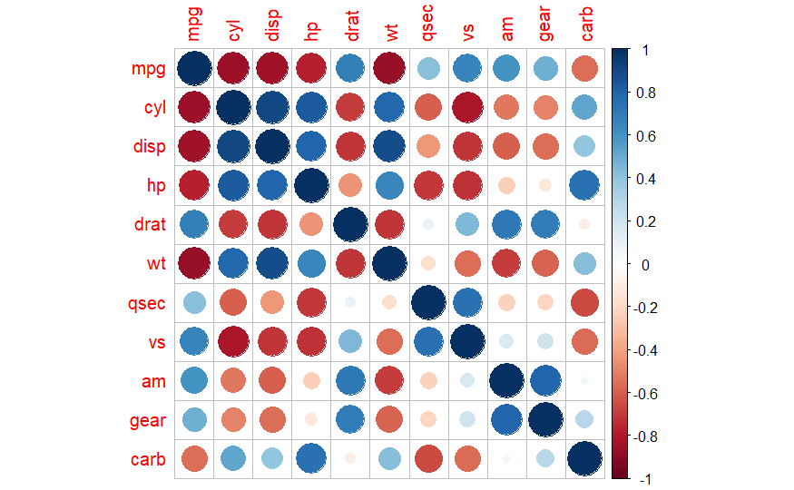

```r
library(corrplot)
corrplot(mcor)
```

##visualize using ggcorr() from GGally package

```r
install.packages("GGally")
```

```r
library(GGally)
```

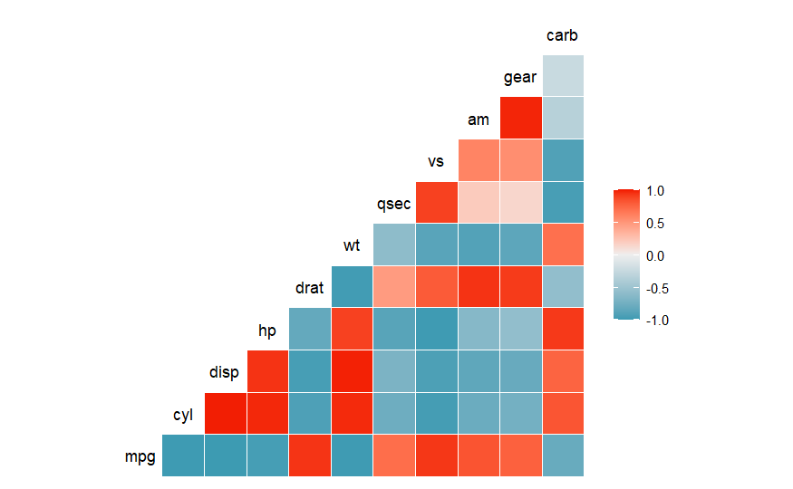

```r
ggcorr(mcor)
```

#exercise

```r
cor.test(mtcars$cyl,mtcars$disp)
```

```
    Pearson's product-moment correlation

data:  mtcars$cyl and mtcars$disp
t = 11.445, df = 30, p-value = 1.803e-12
alternative hypothesis: true correlation is not equal to 0
95 percent confidence interval:
 0.8072442 0.9514607
sample estimates:
      cor
0.9020329
```

#3.3 creating heatmap

```r
nba <- read.csv("http://datasets.flowingdata.com/ppg2008.csv",sep = ",")
head(nba)
```

|  | Name | G | MIN | PTS | FGM | FGA | FGP | FTM | FTA | FTP | X3PM | X3PA | X3PP | ORB | DRB | TRB | AST | STL | BLK | TO | PF |
| --- | --- | --- | --- | --- | --- | --- | --- | --- | --- | --- | --- | --- | --- | --- | --- | --- | --- | --- | --- | --- | --- |
| 1 | Dwyane Wade | 79 | 38.6 | 30.2 | 10.8 | 22.0 | 0.491 | 7.5 | 9.8 | 0.765 | 1.1 | 3.5 | 0.317 | 1.1 | 3.9 | 5.0 | 7.5 | 2.2 | 1.3 | 3.4 | 2.3 |
| 2 | LeBron James | 81 | 37.7 | 28.4 | 9.7 | 19.9 | 0.489 | 7.3 | 9.4 | 0.780 | 1.6 | 4.7 | 0.344 | 1.3 | 6.3 | 7.6 | 7.2 | 1.7 | 1.1 | 3.0 | 1.7 |
| 3 | Kobe Bryant | 82 | 36.2 | 26.8 | 9.8 | 20.9 | 0.467 | 5.9 | 6.9 | 0.856 | 1.4 | 4.1 | 0.351 | 1.1 | 4.1 | 5.2 | 4.9 | 1.5 | 0.5 | 2.6 | 2.3 |
| 4 | Dirk Nowitzki | 81 | 37.7 | 25.9 | 9.6 | 20.0 | 0.479 | 6.0 | 6.7 | 0.890 | 0.8 | 2.1 | 0.359 | 1.1 | 7.3 | 8.4 | 2.4 | 0.8 | 0.8 | 1.9 | 2.2 |
| 5 | Danny Granger | 67 | 36.2 | 25.8 | 8.5 | 19.1 | 0.447 | 6.0 | 6.9 | 0.878 | 2.7 | 6.7 | 0.404 | 0.7 | 4.4 | 5.1 | 2.7 | 1.0 | 1.4 | 2.5 | 3.1 |
| 6 | Kevin Durant | 74 | 39.0 | 25.3 | 8.9 | 18.8 | 0.476 | 6.1 | 7.1 | 0.863 | 1.3 | 3.1 | 0.422 | 1.0 | 5.5 | 6.5 | 2.8 | 1.3 | 0.7 | 3.0 | 1.8 |

##rename row index to be players’names

```r
row.names(nba)<- nba$Name
```

```r
head(nba)
```

|  | Name | G | MIN | PTS | FGM | FGA | FGP | FTM | FTA | FTP | X3PM | X3PA | X3PP | ORB | DRB | TRB | AST | STL | BLK | TO | PF |
| --- | --- | --- | --- | --- | --- | --- | --- | --- | --- | --- | --- | --- | --- | --- | --- | --- | --- | --- | --- | --- | --- |
| Dwyane Wade | Dwyane Wade | 79 | 38.6 | 30.2 | 10.8 | 22.0 | 0.491 | 7.5 | 9.8 | 0.765 | 1.1 | 3.5 | 0.317 | 1.1 | 3.9 | 5.0 | 7.5 | 2.2 | 1.3 | 3.4 | 2.3 |
| LeBron James | LeBron James | 81 | 37.7 | 28.4 | 9.7 | 19.9 | 0.489 | 7.3 | 9.4 | 0.780 | 1.6 | 4.7 | 0.344 | 1.3 | 6.3 | 7.6 | 7.2 | 1.7 | 1.1 | 3.0 | 1.7 |
| Kobe Bryant | Kobe Bryant | 82 | 36.2 | 26.8 | 9.8 | 20.9 | 0.467 | 5.9 | 6.9 | 0.856 | 1.4 | 4.1 | 0.351 | 1.1 | 4.1 | 5.2 | 4.9 | 1.5 | 0.5 | 2.6 | 2.3 |
| Dirk Nowitzki | Dirk Nowitzki | 81 | 37.7 | 25.9 | 9.6 | 20.0 | 0.479 | 6.0 | 6.7 | 0.890 | 0.8 | 2.1 | 0.359 | 1.1 | 7.3 | 8.4 | 2.4 | 0.8 | 0.8 | 1.9 | 2.2 |
| Danny Granger | Danny Granger | 67 | 36.2 | 25.8 | 8.5 | 19.1 | 0.447 | 6.0 | 6.9 | 0.878 | 2.7 | 6.7 | 0.404 | 0.7 | 4.4 | 5.1 | 2.7 | 1.0 | 1.4 | 2.5 | 3.1 |
| Kevin Durant | Kevin Durant | 74 | 39.0 | 25.3 | 8.9 | 18.8 | 0.476 | 6.1 | 7.1 | 0.863 | 1.3 | 3.1 | 0.422 | 1.0 | 5.5 | 6.5 | 2.8 | 1.3 | 0.7 | 3.0 | 1.8 |

##remove the name column

```r
nba <- nba[,2:20]
```

```r
nba
```

|  | G | MIN | PTS | FGM | FGA | FGP | FTM | FTA | FTP | X3PM | X3PA | X3PP | ORB | DRB | TRB | AST | STL | BLK | TO |
| --- | --- | --- | --- | --- | --- | --- | --- | --- | --- | --- | --- | --- | --- | --- | --- | --- | --- | --- | --- |
| Dwyane Wade | 79 | 38.6 | 30.2 | 10.8 | 22.0 | 0.491 | 7.5 | 9.8 | 0.765 | 1.1 | 3.5 | 0.317 | 1.1 | 3.9 | 5.0 | 7.5 | 2.2 | 1.3 | 3.4 |
| LeBron James | 81 | 37.7 | 28.4 | 9.7 | 19.9 | 0.489 | 7.3 | 9.4 | 0.780 | 1.6 | 4.7 | 0.344 | 1.3 | 6.3 | 7.6 | 7.2 | 1.7 | 1.1 | 3.0 |
| Kobe Bryant | 82 | 36.2 | 26.8 | 9.8 | 20.9 | 0.467 | 5.9 | 6.9 | 0.856 | 1.4 | 4.1 | 0.351 | 1.1 | 4.1 | 5.2 | 4.9 | 1.5 | 0.5 | 2.6 |
| Dirk Nowitzki | 81 | 37.7 | 25.9 | 9.6 | 20.0 | 0.479 | 6.0 | 6.7 | 0.890 | 0.8 | 2.1 | 0.359 | 1.1 | 7.3 | 8.4 | 2.4 | 0.8 | 0.8 | 1.9 |
| Danny Granger | 67 | 36.2 | 25.8 | 8.5 | 19.1 | 0.447 | 6.0 | 6.9 | 0.878 | 2.7 | 6.7 | 0.404 | 0.7 | 4.4 | 5.1 | 2.7 | 1.0 | 1.4 | 2.5 |
| Kevin Durant | 74 | 39.0 | 25.3 | 8.9 | 18.8 | 0.476 | 6.1 | 7.1 | 0.863 | 1.3 | 3.1 | 0.422 | 1.0 | 5.5 | 6.5 | 2.8 | 1.3 | 0.7 | 3.0 |
| Kevin Martin | 51 | 38.2 | 24.6 | 6.7 | 15.9 | 0.420 | 9.0 | 10.3 | 0.867 | 2.3 | 5.4 | 0.415 | 0.6 | 3.0 | 3.6 | 2.7 | 1.2 | 0.2 | 2.9 |
| Al Jefferson | 50 | 36.6 | 23.1 | 9.7 | 19.5 | 0.497 | 3.7 | 5.0 | 0.738 | 0.0 | 0.1 | 0.000 | 3.4 | 7.5 | 11.0 | 1.6 | 0.8 | 1.7 | 1.8 |
| Chris Paul | 78 | 38.5 | 22.8 | 8.1 | 16.1 | 0.503 | 5.8 | 6.7 | 0.868 | 0.8 | 2.3 | 0.364 | 0.9 | 4.7 | 5.5 | 11.0 | 2.8 | 0.1 | 3.0 |
| Carmelo Anthony | 66 | 34.5 | 22.8 | 8.1 | 18.3 | 0.443 | 5.6 | 7.1 | 0.793 | 1.0 | 2.6 | 0.371 | 1.6 | 5.2 | 6.8 | 3.4 | 1.1 | 0.4 | 3.0 |

[output cut: 40 more lines]

###heatmap() expects input as matrix but we have a dataframe so we have to convert df to matrix

```r
nbaMatrix <- data.matrix(nba
)
```

###plotting a heatmap

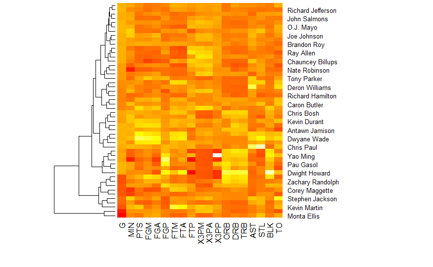

```r
heatmap(nbaMatrix,Rowv = NULL, Colv = NA,col = heat.colors(256),scale = "column",margins = c(5,10))
```